# Lab 05 - APIs and Web Scraping

```python
import pandas as pd
import numpy as np
import requests
from bs4 import BeautifulSoup
from io import StringIO
import re
import json
import time
from plotnine import *
import warnings
warnings.filterwarnings('ignore')
```

# Learning Goals

- Use a real-world API to make queries and process JSON data
- Handle API pagination to fetch large datasets
- Use web scraping to extract tables from Wikipedia
- Use regular expressions to clean scraped data
- Merge datasets from different sources
- Practice your GitHub skills

##### Download lab `.qmd` and dataset [here](https://github.com/JSC370/JSC370-2026/tree/main/labs/lab5)

# Deliverables

Upload your html and qmd to Quercus by 11:59 pm Wednesday February 4th, 2026.

# Lab Description

In this lab, we will practice using APIs and web scraping to obtain and combine movie data from different sources. We will use [The Movie Database (TMDB) API](https://developer.themoviedb.org/docs/getting-started) to fetch movie information and scrape the [Wikipedia page on Academy Award-winning films](https://en.wikipedia.org/wiki/List_of_Academy_Award%E2%80%93winning_films) to get Oscar data, just like in lecture!

**Before starting:** Sign up for a free TMDB API key at [themoviedb.org](https://www.themoviedb.org/settings/api). You’ll need it for Question 1.

## Question 1: Fetching movie data from the TMDB API

The TMDB API allows us to discover movies, get details, and search for films. The base URL is:

```
https://api.themoviedb.org/3
```

### 1a. Set up and discover movies

Replace `"YOUR_API_KEY"` with your actual TMDB API key. Then use the `/discover/movie` endpoint to find top-grossing movies.

Refer to the [TMDB Discover API docs](https://developer.themoviedb.org/reference/discover-movie) and fill in the query parameters below:

```python
# TMDB API configuration
BASE_URL = "https://api.themoviedb.org/3"
API_KEY = "c4d84fc4d49e2e6e1d318959a68f3bcd"  # Replace with your API key!

# Discover top-grossing movies
url = f"{BASE_URL}/discover/movie"

# YOUR CODE HERE: Fill in the query parameters
# - Sort by revenue in descending order
# - Start with page 1
params = {
    "api_key": API_KEY,
    "sort_by": "revenue.desc",
    "page": 1
}

response = requests.get(url, params=params, timeout=30)
print(f"Status Code: {response.status_code}")
print(f"Request URL: {response.url}")
```

```
Status Code: 200
Request URL: https://api.themoviedb.org/3/discover/movie?api_key=c4d84fc4d49e2e6e1d318959a68f3bcd&sort_by=revenue.desc&page=1
```

### 1b. Examine the JSON response

The API returns a JSON object. Parse it and explore its structure.

```python
data = response.json()

# YOUR CODE HERE:
# 1. Print the total number of results (hint: data.get('total_results'))
print(f"Total number of results: {data.get('total_results')}")
# 2. Print the total number of pages
print(f"Total number of pages: {data.get('total_pages')}")
# 3. Print how many movies are on this page (hint: len(data.get('results', [])))
print(f"Number of movies on this page: {len(data.get('results', []))}")
```

```
Total number of results: 1103828
Total number of pages: 55192
Number of movies on this page: 20
```

### 1c. Fetch movie details and build a DataFrame

The `/discover/movie` endpoint returns basic info (id, title, popularity, vote_average), but not budget or revenue. To get those, we need to call the `/movie/{id}` endpoint for each movie.

First, collect movie IDs from multiple pages of discover results. Then fetch details for each movie. Build a DataFrame with the following columns: `movie_id`, `title`, `release_date`, `popularity`, `revenue`, `budget`, `vote_average`.

**Important:** Use `time.sleep(0.1)` between requests to respect rate limits.

#### Step 1: Get the movie IDs

```python
import math

# YOUR CODE HERE:
# The discover endpoint returns 20 movies per page.
# Calculate how many pages you need if you want to fetch 100 movies.
# Then loop through the pages, collecting movie IDs.

MOVIES_COUNT = 100
MOVIES_PER_PAGE = 20
n_pages = math.ceil(MOVIES_COUNT / MOVIES_PER_PAGE)

all_movie_ids = []

for page in range(1, n_pages+1):
    params = {
        "api_key": API_KEY,
        "sort_by": "revenue.desc",
        "page": page
    }
    # 1. Make the GET request
    response = requests.get(url, params=params, timeout=30)

    # 2. Parse the JSON response
    data = response.json()

    # 3. Extract the 'id' from each movie in results and append to all_movie_ids
    for movie in data.get('results', []):
        all_movie_ids.append(movie['id'])

    # 4. Sleep for 0.1 seconds between requests
    time.sleep(0.1)

print(f"Collected {len(all_movie_ids)} movie IDs")
```

```
Collected 100 movie IDs
```

#### Step 2: For each movie ID, fetch details

```python
# YOUR CODE HERE:
# Loop through all_movie_ids and for each movie:
#   1. GET f"{BASE_URL}/movie/{mid}" with api_key param -> parse JSON
#   2. Append a dict with: movie_id, title, release_date, popularity,
#      revenue, budget, vote_average, genres
#      Hint: use detail.get('key') to safely extract each field
#   3. Sleep 0.25 seconds between requests
#   4. Optionally print progress every 20 movies

detailed_movies = []
for i, mid in enumerate(all_movie_ids):
    # 1. GET movie details endpoint with api_key param -> parse JSON
    detail_url = f"{BASE_URL}/movie/{mid}"
    response = requests.get(detail_url, params={"api_key": API_KEY}, timeout=30)
    detail = response.json()

    # 2. Append a dict with required fields
    detailed_movies.append({
        "movie_id": mid,
        "title": detail.get("title"),
        "release_date": detail.get("release_date"),
        "popularity": detail.get("popularity"),
        "revenue": detail.get("revenue"),
        "budget": detail.get("budget"),
        "vote_average": detail.get("vote_average"),
        "genres": detail.get("genres")
    })

    # 3. Sleep 0.25 seconds between requests
    time.sleep(0.25)

    # 4. Print progress every 20 movies
    if (i + 1) % 20 == 0:
        print(f"Fetched {i + 1}/{len(all_movie_ids)} movies...")

df_movies = pd.DataFrame(detailed_movies)
print(f"Fetched details for {len(df_movies)} movies")
df_movies.head(10)
```

```
Fetched 20/100 movies...
Fetched 40/100 movies...
Fetched 60/100 movies...
Fetched 80/100 movies...
Fetched 100/100 movies...
Fetched details for 100 movies
```

|  | movie_id | title | release_date | popularity | revenue | budget | vote_average | genres |
| --- | --- | --- | --- | --- | --- | --- | --- | --- |
| 0 | 19995 | Avatar | 2009-12-16 | 64.6544 | 2923706026 | 237000000 | 7.599 | [{'id': 28, 'name': 'Action'}, {'id': 12, 'nam... |
| 1 | 299534 | Avengers: Endgame | 2019-04-24 | 24.4649 | 2799439100 | 356000000 | 8.236 | [{'id': 12, 'name': 'Adventure'}, {'id': 878, ... |
| 2 | 76600 | Avatar: The Way of Water | 2022-12-14 | 33.9041 | 2353096253 | 350000000 | 7.599 | [{'id': 28, 'name': 'Action'}, {'id': 12, 'nam... |
| 3 | 597 | Titanic | 1997-12-18 | 29.8839 | 2264162353 | 200000000 | 7.902 | [{'id': 18, 'name': 'Drama'}, {'id': 10749, 'n... |
| 4 | 980477 | Ne Zha 2 | 2025-01-29 | 29.3181 | 2259822417 | 80000000 | 8.108 | [{'id': 16, 'name': 'Animation'}, {'id': 14, '... |
| 5 | 140607 | Star Wars: The Force Awakens | 2015-12-15 | 13.1939 | 2068223624 | 245000000 | 7.251 | [{'id': 12, 'name': 'Adventure'}, {'id': 28, '... |
| 6 | 299536 | Avengers: Infinity War | 2018-04-25 | 35.4315 | 2052415039 | 300000000 | 8.235 | [{'id': 12, 'name': 'Adventure'}, {'id': 28, '... |
| 7 | 634649 | Spider-Man: No Way Home | 2021-12-15 | 31.2664 | 1921847111 | 200000000 | 7.933 | [{'id': 28, 'name': 'Action'}, {'id': 12, 'nam... |
| 8 | 1084242 | Zootopia 2 | 2025-11-26 | 206.7752 | 1802806721 | 150000000 | 7.615 | [{'id': 16, 'name': 'Animation'}, {'id': 35, '... |
| 9 | 1022789 | Inside Out 2 | 2024-06-11 | 20.9537 | 1698863816 | 200000000 | 7.547 | [{'id': 16, 'name': 'Animation'}, {'id': 12, '... |

To save time, read in the saved dataset of 10,000 movies and do a summary so we know what to clean.

```python
df_movies = pd.read_csv("movies.csv")
df_movies.describe()
```

|  | movie_id | popularity | revenue | budget | vote_average |
| --- | --- | --- | --- | --- | --- |
| count | 1.000000e+04 | 10000.000000 | 1.000000e+04 | 1.000000e+04 | 10000.000000 |
| mean | 2.233297e+05 | 3.960426 | 8.040872e+07 | 2.508906e+07 | 6.421749 |
| std | 3.401565e+05 | 11.169887 | 1.636094e+08 | 4.012444e+07 | 1.119996 |
| min | 6.000000e+00 | 0.000000 | 4.678632e+06 | 0.000000e+00 | 0.000000 |
| 25% | 1.066075e+04 | 1.288800 | 1.064562e+07 | 1.000000e+06 | 5.963000 |
| 50% | 3.740150e+04 | 2.513550 | 2.514544e+07 | 1.029226e+07 | 6.525000 |
| 75% | 3.459385e+05 | 4.836425 | 7.612413e+07 | 3.000000e+07 | 7.087000 |
| max | 1.625321e+06 | 713.150600 | 2.923706e+09 | 5.839000e+08 | 10.000000 |

### 1d. Clean the data

Examine the data with `df_movies.describe()`. Look for variables with unrealistic values (e.g., budget of 0, extreme popularity values). Clean as needed and extract the year from `release_date`.

```python
# YOUR CODE HERE:
# 1. Examine the data with describe() to identify issues
display(df_movies.describe())
# 2. Remove movies with unrealistic values (e.g., budget == 0, extreme popularity)
df_movies = df_movies[df_movies['budget'] != 0]

# 3. Extract year from release_date
df_movies['year'] = pd.to_datetime(df_movies['release_date']).dt.year

# 4. Print how many movies remain
display(len(df_movies))
```

|  | movie_id | popularity | revenue | budget | vote_average |
| --- | --- | --- | --- | --- | --- |
| count | 1.000000e+04 | 10000.000000 | 1.000000e+04 | 1.000000e+04 | 10000.000000 |
| mean | 2.233297e+05 | 3.960426 | 8.040872e+07 | 2.508906e+07 | 6.421749 |
| std | 3.401565e+05 | 11.169887 | 1.636094e+08 | 4.012444e+07 | 1.119996 |
| min | 6.000000e+00 | 0.000000 | 4.678632e+06 | 0.000000e+00 | 0.000000 |
| 25% | 1.066075e+04 | 1.288800 | 1.064562e+07 | 1.000000e+06 | 5.963000 |
| 50% | 3.740150e+04 | 2.513550 | 2.514544e+07 | 1.029226e+07 | 6.525000 |
| 75% | 3.459385e+05 | 4.836425 | 7.612413e+07 | 3.000000e+07 | 7.087000 |
| max | 1.625321e+06 | 713.150600 | 2.923706e+09 | 5.839000e+08 | 10.000000 |

```
7829
```

## Question 2: Scraping Oscar data from Wikipedia

Now let’s scrape the [List of Academy Award-winning films](https://en.wikipedia.org/wiki/List_of_Academy_Award%E2%80%93winning_films) from Wikipedia, just like in lecture.

### 2a. Fetch and parse the Wikipedia page

Look at what tables are on this website.

```python
OSCARS_URL = "https://en.wikipedia.org/wiki/List_of_Academy_Award%E2%80%93winning_films"

# Include headers to identify ourselves
HEADERS = {
    "User-Agent": "jsc370-class-project/1.0 (educational use)",
    "Accept-Language": "en-US,en;q=0.9",
}

# Fetch the page
oscars_request = requests.get(OSCARS_URL, headers=HEADERS, timeout=30)
print(f"Status code: {oscars_request.status_code}")

# Parse all tables
osc_tables = pd.read_html(StringIO(oscars_request.text))
print(f"Found {len(osc_tables)} tables")

# Examine the tables to find the right one
for i, table in enumerate(osc_tables):
    print(f"\nTable {i}: {table.shape[0]} rows x {table.shape[1]} cols")
    print(f"  Columns: {table.columns.tolist()}")
```

```
Status code: 200
Found 2 tables

Table 0: 1387 rows x 4 cols
  Columns: ['Film', 'Year', 'Awards', 'Nominations']

Table 1: 10 rows x 2 cols
  Columns: ['vteAcademy Awards lists', 'vteAcademy Awards lists.1']
```

### 2b. Extract the main Oscar winners table

Extract the first table on the website, summarize the data you get.

```python
# YOUR CODE HERE: Select the correct table index based on the output above
# The main table should have columns like: Film, Year, Awards, Nominations

osc = osc_tables[0]
print(f"Shape: {osc.shape}")
osc.head(10)
```

```
Shape: (1387, 4)
```

|  | Film | Year | Awards | Nominations |
| --- | --- | --- | --- | --- |
| 0 | Anora | 2024 | 5 | 6 |
| 1 | The Brutalist | 2024 | 3 | 10 |
| 2 | Emilia Pérez | 2024 | 2 | 13 |
| 3 | Wicked | 2024 | 2 | 10 |
| 4 | Dune: Part Two | 2024 | 2 | 5 |
| 5 | Conclave | 2024 | 1 | 8 |
| 6 | The Substance | 2024 | 1 | 5 |
| 7 | I'm Still Here | 2024 | 1 | 3 |
| 8 | Flow | 2024 | 1 | 2 |
| 9 | A Real Pain | 2024 | 1 | 2 |

Check variable types to see if we need to clean.

```python
# YOUR CODE HERE: Check the dtypes of the Oscar table
# Hint: osc.dtypes
display(osc.dtypes)
```

```
Film           object
Year           object
Awards         object
Nominations    object
dtype: object
```

### 2c. Clean the columns using regular expressions

Make `Year`, `Awards`, and `Nominations` numeric. You may need to remove footnotes like `[1]` and handle strings like `2020/21`.

Use regex to extract just the 4-digit `Year` and integers for `Awards` and `Nominations`.

```python
# YOUR CODE HERE:
# For each of Year, Awards, Nominations:
#   1. Convert to string
#   2. Remove wiki-style footnotes like [2], [10] using .str.replace()
#   3. Extract the first number using .str.extract()
#   4. Convert to numeric with pd.to_numeric()

osc['Year'] = osc['Year'].astype(str).str.extract(r'(\d{4})')[0].astype(int)

osc['Awards'] = osc['Awards'].astype(str).str.extract(r'(\d+)')[0].astype(int)

osc['Nominations'] = osc['Nominations'].astype(str).str.extract(r'(\d+)')[0].astype(int)

# Verify the dtypes after cleaning
display(osc['Year'].unique())
display(osc['Awards'].unique())
display(osc['Nominations'].unique())

osc.dtypes
```

```
array([2024, 2023, 2022, 2021, 2020, 2019, 2018, 2017, 2016, 2015, 2014,
       2013, 2012, 2011, 2010, 2009, 2008, 2007, 2006, 2005, 2004, 2003,
       2002, 2001, 2000, 1999, 1998, 1997, 1996, 1995, 1994, 1993, 1992,
       1991, 1990, 1989, 1988, 1987, 1986, 1985, 1984, 1983, 1982, 1981,
       1980, 1979, 1978, 1977, 1976, 1975, 1974, 1973, 1972, 1971, 1970,
       1969, 1968, 1967, 1966, 1965, 1964, 1927, 1954, 1949, 1938, 1951,
       1943, 1960, 1953, 1957, 1950, 1929, 1941, 1958, 1963, 1956, 1945,
       1946, 1936, 1940, 1937, 1947, 1952, 1931, 1942, 1959, 1948, 1962,
       1961, 1928, 1955, 1935, 1939, 1932, 1930, 1934, 1944])
```

```
array([ 5,  3,  2,  1,  7,  4,  6,  0,  8, 11,  9, 10])
```

```
array([ 6, 10, 13,  5,  8,  3,  2,  1, 11,  9,  4,  7, 12,  0, 14])
```

```
Film           object
Year            int64
Awards          int64
Nominations     int64
dtype: object
```

### 2d. Explore the Oscar data

Do some summary statistics on the scraped Oscar data.

```python
# YOUR CODE HERE:
# 1. Do a general summary with describe()
# 2. How many films are in the Oscar dataset?
# 3. What is the range of years?
# 4. What film has the most Awards?
# 5. What is the average number of nominations?
display(osc.describe())
print(f"Number of films: {osc.shape[0]}")
print(f"Range of years: {osc['Year'].min()} to {osc['Year'].max()}")
max_awards = osc['Awards'].max()
top_award_films = osc.loc[osc['Awards'].eq(max_awards), 'Film'].tolist()
print(f"Film(s) with most Awards ({max_awards}): {top_award_films}")
print(f"Average number of nominations: {osc['Nominations'].mean():.2f}")
```

|  | Year | Awards | Nominations |
| --- | --- | --- | --- |
| count | 1387.000000 | 1387.000000 | 1387.000000 |
| mean | 1976.350397 | 1.573901 | 3.619322 |
| std | 27.699346 | 1.389814 | 3.136275 |
| min | 1927.000000 | 0.000000 | 0.000000 |
| 25% | 1952.000000 | 1.000000 | 1.000000 |
| 50% | 1976.000000 | 1.000000 | 2.000000 |
| 75% | 2001.000000 | 2.000000 | 5.500000 |
| max | 2024.000000 | 11.000000 | 14.000000 |

```
Number of films: 1387
Range of years: 1927 to 2024
Film(s) with most Awards (11): ['The Lord of the Rings: The Return of the King', 'Titanic', 'Ben-Hur']
Average number of nominations: 3.62
```

## Question 3: Merging TMDB movies with Oscar data

Now let’s combine the TMDB movie data from Question 1 with the scraped Oscar data from Question 2. We want to do a **left join** that keeps all TMDB movies and adds Oscar award information where available.

### 3a. Prepare both datasets for merging

Before merging, make sure the title and year columns are clean and compatible across both datasets.

```python
# YOUR CODE HERE:
# 1. Make sure df_movies has a clean year column
df_movies['year'] = df_movies['release_date'].astype(str).str.extract(r'(\d{4})')[0]
df_movies['year'] = pd.to_numeric(df_movies['year'], errors='coerce').astype('Int64')

# 2. Check the columns we'll merge on
print("TMDB movies columns:", df_movies.columns.tolist())
print("Oscar data columns:", osc.columns.tolist())
print("\nMerge keys:")
print("  df_movies: 'title' and 'year'")
print("  osc: 'Film' and 'Year'")

# 3. Preview what we're merging (number of rows in each)
print(f"\nNumber of TMDB movies: {len(df_movies)}")
print(f"Number of Oscar films: {len(osc)}")

# 4. Look at a few titles from each to check formatting
print("\nSample TMDB titles:")
display(df_movies[['title', 'year']].head(5))
print("\nSample Oscar titles:")
display(osc[['Film', 'Year']].head(5))
```

```
TMDB movies columns: ['movie_id', 'title', 'release_date', 'popularity', 'revenue', 'budget', 'vote_average', 'genres', 'year']
Oscar data columns: ['Film', 'Year', 'Awards', 'Nominations']

Merge keys:
  df_movies: 'title' and 'year'
  osc: 'Film' and 'Year'

Number of TMDB movies: 7829
Number of Oscar films: 1387

Sample TMDB titles:
```

|  | title | year |
| --- | --- | --- |
| 0 | Avatar | 2009 |
| 1 | Avengers: Endgame | 2019 |
| 2 | Avatar: The Way of Water | 2022 |
| 3 | Titanic | 1997 |
| 4 | Ne Zha 2 | 2025 |

```
Sample Oscar titles:
```

|  | Film | Year |
| --- | --- | --- |
| 0 | Anora | 2024 |
| 1 | The Brutalist | 2024 |
| 2 | Emilia Pérez | 2024 |
| 3 | Wicked | 2024 |
| 4 | Dune: Part Two | 2024 |

### 3b. Merge the datasets

Perform a left join to keep all TMDB movies and add the Awards and Nominations columns from the Oscar data. Fill missing awards with 0 (movies that didn’t win any Oscars).

```python
# YOUR CODE HERE:
# 1. Left join df_movies with osc on title and year
#    Hint: df_movies has 'title' and 'year', osc has 'Film' and 'Year'
merged = df_movies.merge(
    osc,
    how='left',
    left_on=['title', 'year'],
    right_on=['Film', 'Year']
)
# 2. Fill missing Awards and Nominations with 0
merged['Awards'] = merged['Awards'].fillna(0).astype('Int64')
merged['Nominations'] = merged['Nominations'].fillna(0).astype('Int64')
# 3. Create an indicator for whether the movie won any Oscars
merged['won_oscar'] = (merged['Awards'] > 0).astype(int)
# 4. Print summary of the merge (total movies, Oscar winners, non-winners)
print(f"Total movies in merged dataset: {len(merged)}")
print(f"Oscar winners: {merged['won_oscar'].sum()}")
print(f"Non-Oscar winners: {(merged['won_oscar'] == 0).sum()}")
print(f"\nMerged dataset shape: {merged.shape}")
display(merged.head(10))
```

```
Total movies in merged dataset: 7829
Oscar winners: 549
Non-Oscar winners: 7280

Merged dataset shape: (7829, 14)
```

|  | movie_id | title | release_date | popularity | revenue | budget | vote_average | genres | year | Film | Year | Awards | Nominations | won_oscar |
| --- | --- | --- | --- | --- | --- | --- | --- | --- | --- | --- | --- | --- | --- | --- |
| 0 | 19995 | Avatar | 2009-12-16 | 40.8368 | 2923706026 | 237000000 | 7.600 | [{'id': 28, 'name': 'Action'}, {'id': 12, 'nam... | 2009 | Avatar | 2009.0 | 3 | 9 | 1 |
| 1 | 299534 | Avengers: Endgame | 2019-04-24 | 16.6766 | 2799439100 | 356000000 | 8.236 | [{'id': 12, 'name': 'Adventure'}, {'id': 878, ... | 2019 | NaN | NaN | 0 | 0 | 0 |
| 2 | 76600 | Avatar: The Way of Water | 2022-12-14 | 36.5326 | 2353096253 | 350000000 | 7.600 | [{'id': 28, 'name': 'Action'}, {'id': 12, 'nam... | 2022 | Avatar: The Way of Water | 2022.0 | 1 | 4 | 1 |
| 3 | 597 | Titanic | 1997-12-18 | 32.0289 | 2264162353 | 200000000 | 7.900 | [{'id': 18, 'name': 'Drama'}, {'id': 10749, 'n... | 1997 | Titanic | 1997.0 | 11 | 14 | 1 |
| 4 | 980477 | Ne Zha 2 | 2025-01-29 | 33.1112 | 2259822417 | 80000000 | 8.108 | [{'id': 16, 'name': 'Animation'}, {'id': 14, '... | 2025 | NaN | NaN | 0 | 0 | 0 |
| 5 | 140607 | Star Wars: The Force Awakens | 2015-12-15 | 9.6842 | 2068223624 | 245000000 | 7.252 | [{'id': 12, 'name': 'Adventure'}, {'id': 28, '... | 2015 | NaN | NaN | 0 | 0 | 0 |
| 6 | 299536 | Avengers: Infinity War | 2018-04-25 | 27.4076 | 2052415039 | 300000000 | 8.234 | [{'id': 12, 'name': 'Adventure'}, {'id': 28, '... | 2018 | NaN | NaN | 0 | 0 | 0 |
| 7 | 634649 | Spider-Man: No Way Home | 2021-12-15 | 24.5079 | 1921847111 | 200000000 | 7.900 | [{'id': 28, 'name': 'Action'}, {'id': 12, 'nam... | 2021 | NaN | NaN | 0 | 0 | 0 |
| 8 | 1084242 | Zootopia 2 | 2025-11-26 | 428.3987 | 1744338246 | 150000000 | 7.600 | [{'id': 16, 'name': 'Animation'}, {'id': 35, '... | 2025 | NaN | NaN | 0 | 0 | 0 |
| 9 | 1022789 | Inside Out 2 | 2024-06-11 | 20.2485 | 1698863816 | 200000000 | 7.546 | [{'id': 16, 'name': 'Animation'}, {'id': 12, '... | 2024 | NaN | NaN | 0 | 0 | 0 |

### 3c. Examine the merged data

```python
# YOUR CODE HERE:
# 1. Show the Oscar-winning movies in the dataset
print(f"Oscar-winning movies: {merged[merged['won_oscar'] == 1]['title'].unique()}")
# 2. Compare average budget and revenue for Oscar winners vs non-winners
print(f"Average budget for Oscar winners: {merged[merged['won_oscar'] == 1]['budget'].mean()}")
print(f"Average revenue for Oscar winners: {merged[merged['won_oscar'] == 1]['revenue'].mean()}")
print(f"Average budget for non-Oscar winners: {merged[merged['won_oscar'] == 0]['budget'].mean()}")
print(f"Average revenue for non-Oscar winners: {merged[merged['won_oscar'] == 0]['revenue'].mean()}")
# 3. Which Oscar-winning movie had the highest revenue? Highest budget?
winners = merged.loc[merged['won_oscar'].eq(1)].copy()
top_rev = winners.loc[winners['revenue'].idxmax(), ['title', 'revenue']]
top_budget = winners.loc[winners['budget'].idxmax(), ['title', 'budget']]
print(f"Top-revenue Oscar winner: {top_rev['title']} (revenue={top_rev['revenue']})")
print(f"Top-budget Oscar winner: {top_budget['title']} (budget={top_budget['budget']})")
```

```
Oscar-winning movies: ['Avatar' 'Avatar: The Way of Water' 'Titanic' 'Top Gun: Maverick'
 'Barbie' 'Black Panther' 'Frozen'
 'The Lord of the Rings: The Return of the King' 'Skyfall' 'Joker'
 'Toy Story 4' 'Toy Story 3' "Pirates of the Caribbean: Dead Man's Chest"
 'Zootopia' 'Alice in Wonderland' 'The Dark Knight' 'The Jungle Book'
 'Oppenheimer' 'Finding Nemo' 'The Lord of the Rings: The Two Towers'
 'Jurassic Park' 'Bohemian Rhapsody' 'Spectre'
 'The Lord of the Rings: The Fellowship of the Ring'
 'Black Panther: Wakanda Forever' 'Inside Out' 'Inception'
 'Independence Day' 'Coco' 'Fantastic Beasts and Where to Find Them'
 'Spider-Man 2' 'Star Wars' 'No Time to Die' 'The Lion King' 'Wicked'
 'Suicide Squad' 'Interstellar'
 'The Chronicles of Narnia: The Lion, the Witch and the Wardrobe' 'Up'
 'Gravity' 'Dune: Part Two' 'Forrest Gump' 'Big Hero 6' 'Sing'
 'The Incredibles' 'Ratatouille' 'Life of Pi' 'Men in Black'
 'Monsters, Inc.' 'King Kong' 'American Sniper' 'Brave'
 'The Empire Strikes Back' 'The Revenant' 'Dunkirk'
 'Terminator 2: Judgment Day' 'La La Land' 'Ghost' 'Aladdin' 'Shrek'
 'Saving Private Ryan' 'Indiana Jones and the Last Crusade' 'Jaws'
 'Gladiator' 'The Matrix' 'Pearl Harbor' 'Tarzan' '1917'
 'The Bourne Ultimatum' 'Les Misérables' 'The Exorcist' 'Mrs. Doubtfire'
 'A Star Is Born' 'Django Unchained' 'Beauty and the Beast'
 'Dances with Wolves' "The King's Speech" 'Batman' 'Dune'
 'Gone with the Wind' 'Spider-Man: Into the Spider-Verse'
 'Raiders of the Lost Ark' 'Star Trek' 'Happy Feet' 'Back to the Future'
 'Mad Max: Fury Road' 'Slumdog Millionaire' 'The Golden Compass' 'Tenet'
 'Top Gun' 'American Beauty' 'Apollo 13' 'Rain Man' 'The Fugitive'
 'The Great Gatsby' 'Speed' 'Pocahontas' 'How the Grinch Stole Christmas'
 'The Curious Case of Benjamin Button'
 'Indiana Jones and the Temple of Doom' 'Little Women'
 'Who Framed Roger Rabbit' 'Black Swan' 'Green Book'
 'Inglourious Basterds' "Schindler's List" 'A Beautiful Mind'
 'As Good as It Gets' 'The Blind Side'
 'Close Encounters of the Third Kind' 'Chicago' 'The Boy and the Heron'
 'The Departed' 'Shakespeare in Love' 'The Sound of Music' 'Lincoln'
 'Jerry Maguire' 'The Silence of the Lambs' 'Encanto' 'Blade Runner 2049'
 'The Full Monty' 'Parasite' 'Erin Brockovich' 'Get Out' 'Babe' 'Rango'
 'The Godfather' '8 Mile' 'Silver Linings Playbook' 'Dead Poets Society'
 'The Imitation Game' 'Cruella' 'The Girl with the Dragon Tattoo' 'Juno'
 'Argo' 'The English Patient' 'Out of Africa' 'Good Will Hunting'
```

[output cut: 102 more lines]

```
 'Topsy-Turvy' "Gentleman's Agreement" 'The Hustler' 'Rebecca'
 'Women Talking' 'Kolya' 'Anchors Aweigh' "You Can't Take It with You"
 'Lilies of the Field' 'A Place in the Sun' 'Spellbound'
 'An American in Paris' 'The Fortune Cookie' 'A Patch of Blue'
 'Gods and Monsters' 'Affliction' 'Ed Wood' '20 Feet from Stardom'
 'National Velvet' 'The Black Swan' 'Mildred Pierce'
 'The Bachelor and the Bobby-Soxer' 'She Wore a Yellow Ribbon' 'Lili'
 'San Francisco' 'Destination Moon' 'Sunset Boulevard' "No Man's Land"
 'How Green Was My Valley']
Average budget for Oscar winners: 36817042.18032787
Average revenue for Oscar winners: 198698947.10382512
Average budget for non-Oscar winners: 31686549.41607143
Average revenue for non-Oscar winners: 87284742.8967033
Top-revenue Oscar winner: Avatar (revenue=2923706026)
Top-budget Oscar winner: Avatar: The Way of Water (budget=350000000)
```

## Question 4: Visualize the results

### 4a. Compare revenue for Oscar winners vs non-winners

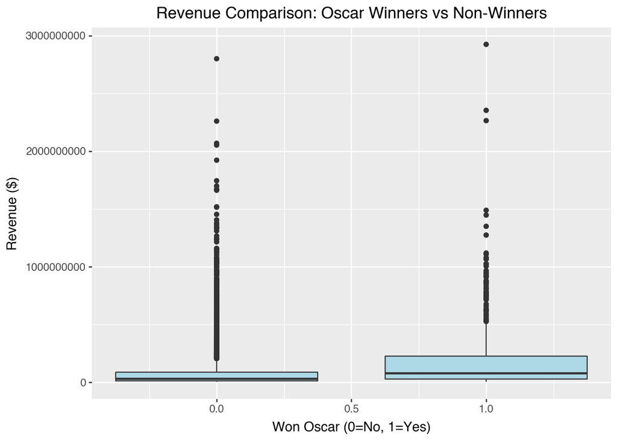

```python
# YOUR CODE HERE: Create a boxplot with plotnine comparing TMDB revenue
# for Oscar winners vs non-winners
(
    ggplot(merged, aes(x='won_oscar', y='revenue', group='won_oscar')) +
    geom_boxplot(fill='lightblue') +
    labs(
        title='Revenue Comparison: Oscar Winners vs Non-Winners',
        x='Won Oscar (0=No, 1=Yes)',
        y='Revenue ($)'
    )
)
```

Summary: The boxplot reveals that Oscar-winning movies have substantially higher median revenue compared to non-winners. The revenue distribution for Oscar winners is also more variable and shifted upward, suggesting that Academy Award-winning films in our dataset tend to be higher-grossing blockbusters. Both groups show outliers, but the overall pattern indicates a positive relationship between Oscar wins and revenue.

### 4b. Scatter plot of budget vs revenue colored by Oscar status

TMDB provides budget data that Wikipedia doesn’t have, so we can explore the budget-revenue relationship.

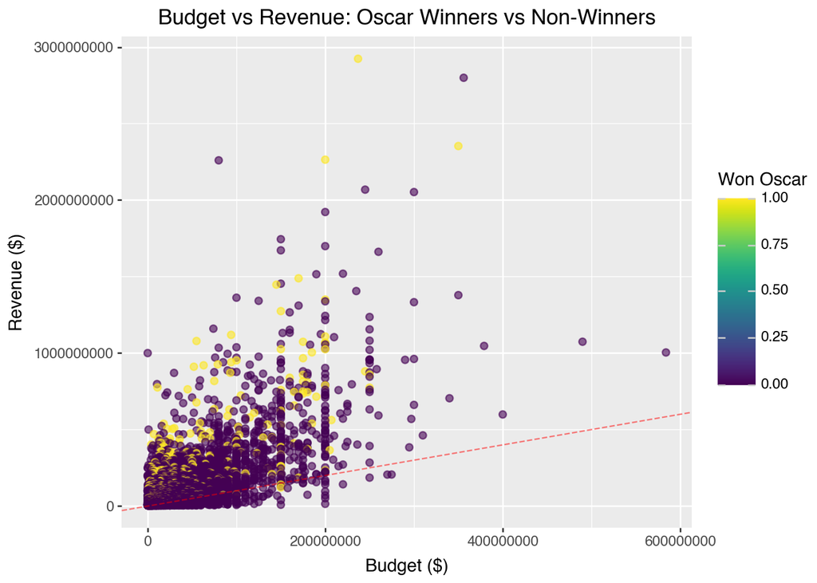

```python
# YOUR CODE HERE: Create a scatter plot with plotnine
# - x-axis: budget
# - y-axis: revenue
# - Color by won_oscar
# - Consider adding geom_abline(slope=1, intercept=0) to show the break-even line
# - Add labels and title
(
    ggplot(merged, aes(x='budget', y='revenue', color='won_oscar')) +
    geom_point(alpha=0.6, size=2) +
    geom_abline(slope=1, intercept=0, linetype='dashed', color='red', alpha=0.5) +
    labs(
        title='Budget vs Revenue: Oscar Winners vs Non-Winners',
        x='Budget ($)',
        y='Revenue ($)',
        color='Won Oscar'
    )
)
```

Summary: The scatter plot shows a strong positive relationship between budget and revenue, with most movies falling above the break-even line. Oscar winners are distributed throughout the plot but appear more frequently among higher budget, higher revenue films. The wide scatter around the trend suggests that while bigger budgets lead to higher revenue, the success of a movie is highly variable and not only determined by production budget.

### 4c. Return on investment

Calculate the return on investment (revenue / budget) and compare Oscar winners vs non-winners.

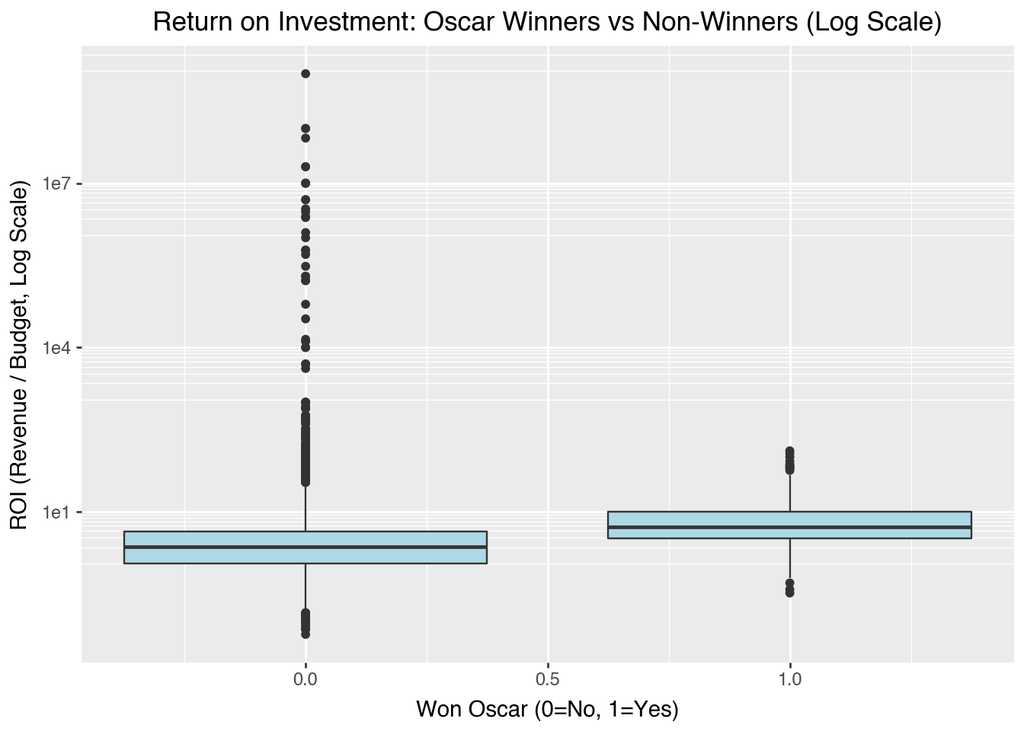

```python
# YOUR CODE HERE:
# 1. Calculate ROI: merged['roi'] = merged['revenue'] / merged['budget']
merged['roi'] = merged['revenue'] / merged['budget']

# 2. Create a boxplot or histogram comparing ROI for Oscar winners vs non-winners
(
    ggplot(merged, aes(x='won_oscar', y='roi', group='won_oscar')) +
    geom_boxplot(fill='lightblue') +
    scale_y_log10() +
    labs(
        title='Return on Investment: Oscar Winners vs Non-Winners (Log Scale)',
        x='Won Oscar (0=No, 1=Yes)',
        y='ROI (Revenue / Budget, Log Scale)'
    )
)
```